# Multi-Layer DNN using R

Benoit and Sarat

20/04/2023

# Goals

In this practice, we mainly use the MNIST dataset to explore classification deep neural networks (DNN) models. At the end of this practice, you should be comfortable to use a software package (here **keras**) to run different models for a classification task. You will explore different models by exploring/tuning different hyperparamaters of the DNN:

- number of layers and nodes
- batch normalization
- regularization technique
- dropout
- weight initialization

# MNIST Data set

## Loading package and dataset

First you have to install **keras** R packages using

```r
install.packages(keras)
```

We load some extra packages that you have to install too.

```r
library(knitr)
library(dplyr)
library(keras)
library(dslabs)
library(tidyr)
library(stringr)
library(purrr)
```

MNIST data are available from the package **dslabs**

```r
library(dslabs)
# Import MNIST training data
mnist <- read_mnist()
mnist_x <- mnist$train$images
mnist_y <- mnist$train$labels
mnist_x_test <- mnist$test$images
mnist_y_test <- mnist$test$labels
dim(mnist_x)
```

```
[1] 60000   784
```

```r
dim(mnist_x_test)
```

```
[1] 10000   784
```

```r
length(mnist_y)
```

```
[1] 60000
```

```r
length(mnist_y_test)
```

```
[1] 10000
```

**Reminder**: Keep in mind that all features need to be numeric for running a feedforward DNN. When you have some categorical features you have to transform into numerical values such as one-hot encoded.

### Scale the data set

The data is in gray scale with each image having 0 to 255 pixels. We thereforemneed to scale the data by the number of pixels.

```r
colnames(mnist_x) <- paste0("V", 1:ncol(mnist_x))
mnist_x <- mnist_x / 255
colnames(mnist_x_test) <- paste0("V", 1:ncol(mnist_x))
mnist_x_test <- mnist_x_test / 255
```

### Transform the outcome

For multi-classification model (multinomial response 0 to 9), **Keras** uses one-hot encoded for the outcome

```r
# One-hot encode response
mnist_y <- to_categorical(mnist_y, 10)
```

```
Loaded Tensorflow version 2.3.1
```

```r
dim(mnist_y)
```

```
[1] 60000    10
```

## Implementation a DNN using Keras

### Procedure

- Initiate a sequential feed-forward DNN using `keras_model_sequential()`
- Add some dense layers.

```r
model <- keras_model_sequential() %>%
  layer_dense(units = 128, input_shape = ncol(mnist_x)) %>%
  layer_dense(units = 64) %>%
  layer_dense(units = 10)
```

Here, we have two hidden layers:

- 128 neurons for the first layer
- 64 for the second
- 10 neurons for the output layer

Note the **input_shape** argument which represents the number of features in the data (here 784)

### Activation

We need to choose some activation function:

```r
model <- keras_model_sequential() %>%
  layer_dense(units = 128, activation = "relu", input_shape = ncol(mnist_x)) %>%
  layer_dense(units = 64, activation = "relu") %>%
  layer_dense(units = 10, activation = "softmax")
```

Here, it is natural to choose the **softmax** function for the output layer. It is the most common to use **ReLU** activation for hidden layer

### Backpropagation and Optimizer

Now, we have to define our objective function to optimize and the optimizer to get a solution. The natural choise here is the **cross entropy** for categorical outcome. **Keras** offers several optimizers:

- Stochastic gradient descent (sgd) optimizer
- Adaptive Moment Estimation (adam)
- rmsprop
- Adaptive learning rate (Adadelta)

We will use in this example **rmsprop** optimizer.

```r
model <- keras_model_sequential() %>%

  # Network architecture
  layer_dense(units = 128, activation = "relu", input_shape = ncol(mnist_x)) %>%
  layer_dense(units = 64, activation = "relu") %>%
  layer_dense(units = 10, activation = "softmax") %>%

  # Backpropagation
  compile(
    loss = 'categorical_crossentropy',
    optimizer = optimizer_rmsprop(),
    metrics = c('accuracy')
  )
```

Note that we define a metric on which the model will be evaluated. We have used the “accuracy” metric to assess the performance of the model

### Summary of our model

```r
summary(model)
```

```
Model: "sequential_2"
________________________________________________________________________________
Layer (type)                        Output Shape                    Param #
================================================================================
dense_8 (Dense)                     (None, 128)                     100480
________________________________________________________________________________
dense_7 (Dense)                     (None, 64)                      8256
________________________________________________________________________________
dense_6 (Dense)                     (None, 10)                      650
================================================================================
Total params: 109,386
Trainable params: 109,386
Non-trainable params: 0
________________________________________________________________________________
```

### Train our model

We will train our model on 25 epochs and a bath size of 128. We also use $20\%$ of our data for the evaluation step during the training phase, meaning that $60,000\times 0.2=12,000$ of the samples are using for the validation step while 48,000 samples are using for the optimization step.

**Reminder:** An epoch describes the number of times the algorithm sees the entire data set. So with a batch size of 128, one epoch is achieved after 375 passes.

```r
# Train the model
set.seed(1)
fit1 <- model %>%
  fit(
    x = mnist_x,
    y = mnist_y,
    epochs = 25,
    batch_size = 128,
    validation_split = 0.2,
    verbose = FALSE
  )

# Display output
fit1
```

```
Final epoch (plot to see history):
        loss: 0.001971
    accuracy: 0.9994
    val_loss: 0.163
val_accuracy: 0.9771
```

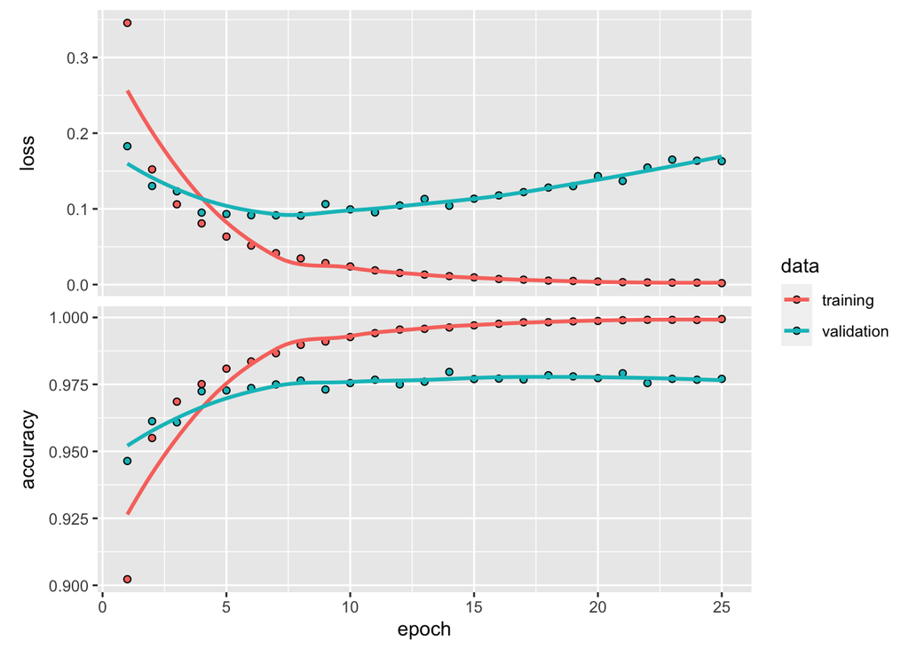

Training and validation performance over 25 epochs.

```r
plot(fit1)
```

We can see that the loss function improves rapidly. However, we can see a potential overfit after 10 epochs. Indeed, the accurary rate of the validation set presents a flat shape after 10 epochs.

### Prediction

We can predict now the class (digits) for a new image:

```r
#model%>% predict_classes(mnist_x_test[1:10,])
model %>% predict(mnist_x_test[1:10,]) %>% k_argmax()
```

```
tf.Tensor([7 2 1 0 4 1 4 9 5 9], shape=(10), dtype=int64)
```

Compared to the true label

```r
mnist_y_test[1:10]
```

```
 [1] 7 2 1 0 4 1 4 9 5 9
```

It looks good ?

```r
#pred <- model%>% predict_classes(mnist_x_test[,])
pred <- model %>% predict(mnist_x_test[,]) %>% k_argmax()
table(as.vector(pred),mnist_y_test)
```

```
   mnist_y_test
       0    1    2    3    4    5    6    7    8    9
  0  974    0    7    0    2    4    8    1    8    3
  1    1 1125    0    0    0    0    3    1    1    2
  2    0    2  997    5    3    0    1    7    4    0
  3    0    2    8  980    1    6    1    3    6    3
  4    0    0    3    0  954    1    4    2    3    5
  5    1    0    0   12    0  876    5    0    7    4
  6    2    2    2    0    3    4  933    0    0    0
  7    1    0    8    3    4    0    0 1006    2    4
  8    1    2    7    2    1    0    3    1  937    1
  9    0    2    0    8   14    1    0    7    6  987
```

```r
sum(diag(table(as.vector(pred),mnist_y_test)))/10000
```

```
[1] 0.9769
```

### Performance on test set

```r
library(caret)
confusionMatrix(factor(as.vector(pred)),factor(mnist_y_test))->res
res$table
```

```
          Reference
Prediction    0    1    2    3    4    5    6    7    8    9
         0  974    0    7    0    2    4    8    1    8    3
         1    1 1125    0    0    0    0    3    1    1    2
         2    0    2  997    5    3    0    1    7    4    0
         3    0    2    8  980    1    6    1    3    6    3
         4    0    0    3    0  954    1    4    2    3    5
         5    1    0    0   12    0  876    5    0    7    4
         6    2    2    2    0    3    4  933    0    0    0
         7    1    0    8    3    4    0    0 1006    2    4
         8    1    2    7    2    1    0    3    1  937    1
         9    0    2    0    8   14    1    0    7    6  987
```

```r
res$overall[1]
```

```
Accuracy
  0.9769
```

## Improve our model by tuning some parameters

### Model complexity

We will explore different model size by playing with the number of hidden layer from 1 to 3 and different number of neurons. Complex models have higher capacity to learn more features and patterns in the data, however they can overfit the training data. We try to maximize a high validation performance while minimizing the complexity of our model. The folowing table present the 9 models we will explore:

9 Models with different complexity according number of layers and nodes per layer.

| Size | Hidden Layers 1 | Hidden Layers 2 | Hidden Layers 3 |
| --- | --- | --- | --- |
| small | 16 | 16, 8 | 16, 8, 4 |
| medium | 64 | 64, 32 | 64, 32, 16 |
| large | 256 | 256, 128 | 256, 128, 64 |

We have 9 models to run !!! better to wrap it into a nice function.

### Small Model: one layer model

```r
compiler <- function(object) {
  compile(
    object,
    loss = 'categorical_crossentropy',
    optimizer = optimizer_rmsprop(),
    metrics = c('accuracy')
  )
}

trainer <- function(object) {
  fit(
    object,
    x = mnist_x,
    y = mnist_y,
    epochs = 25,
    batch_size = 128,
    validation_split = .2,
    verbose = FALSE
    )
}

# One layer models -------------------------------------------------------------
# small  model
`1 layer_small` <- keras_model_sequential() %>%
  layer_dense(units = 16, activation = "relu", input_shape = ncol(mnist_x)) %>%
  layer_dense(units = 10, activation = "softmax") %>%
  compiler() %>%
  trainer()

# medium
`1 layer_medium` <- keras_model_sequential() %>%
  layer_dense(units = 64, activation = "relu", input_shape = ncol(mnist_x)) %>%
  layer_dense(units = 10, activation = "softmax") %>%
  compiler() %>%
  trainer()

# large
`1 layer_large` <- keras_model_sequential() %>%
  layer_dense(units = 256, activation = "relu", input_shape = ncol(mnist_x)) %>%
  layer_dense(units = 10, activation = "softmax") %>%
  compiler() %>%
  trainer()
```

We can plot the results:

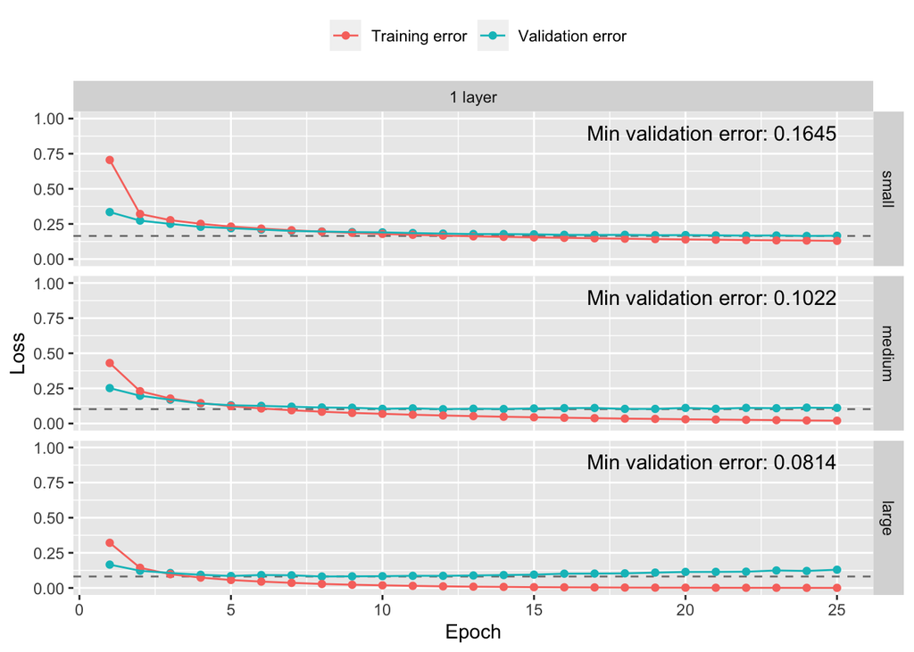

```r
models <- ls(pattern = "layer_")
df <- models %>%
  map(get) %>%
  map(~ data.frame(
    `Validation error` = .$metrics$val_loss,
    `Training error`   = .$metrics$loss,
    epoch = seq_len(.$params$epoch)
    )) %>%
  map2_df(models, ~ mutate(.x, model = .y)) %>%
  separate(model, into = c("Middle layers", "Number of nodes"), sep = "_") %>%
  gather(Validation, Loss, Validation.error:Training.error) %>%
  mutate(
    Validation = str_replace_all(Validation, "\\.", " "),
    `Number of nodes` = factor(`Number of nodes`, levels = c("small", "medium", "large"))
    )

best <- df %>%
  filter(Validation == "Validation error") %>%
  group_by(`Middle layers`, `Number of nodes`) %>%
  filter(Loss == min(Loss)) %>%
  mutate(label = paste("Min validation error:", round(Loss, 4)))

ggplot(df, aes(epoch, Loss)) +
  geom_hline(data = best, aes(yintercept = Loss), lty = "dashed", color = "grey50") +
  geom_text(data = best, aes(x = 25, y = 0.95, label = label), size = 4, hjust = 1, vjust = 1) +
  geom_point(aes(color = Validation)) +
  geom_line(aes(color = Validation)) +
  facet_grid(`Number of nodes` ~ `Middle layers`, scales = "free_y") +
  scale_y_continuous(limits = c(0, 1)) +
  theme(legend.title = element_blank(),
        legend.position = "top") +
  xlab("Epoch")
```

## TASK1

- Repeat it for the 2-layer and 3-layer model.

You should get a figure similar as the following one:

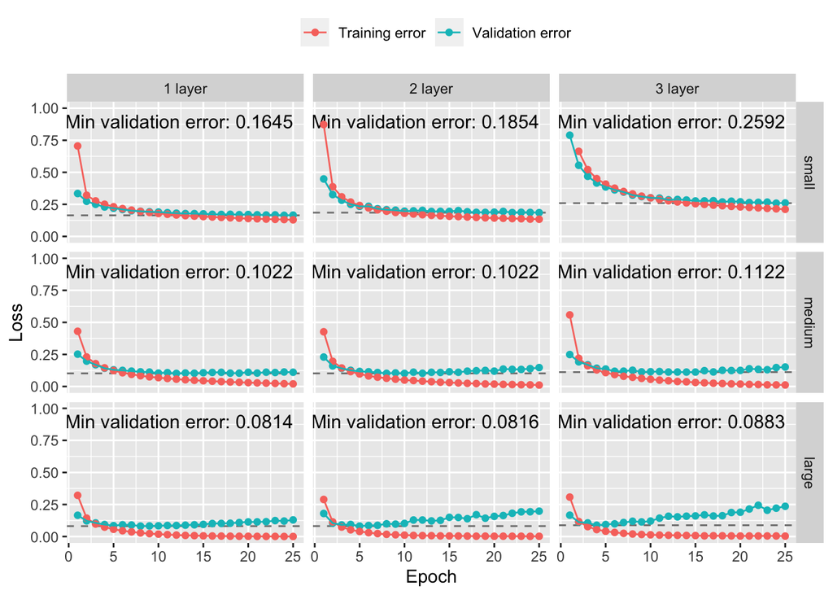

```r
# Two layer models -------------------------------------------------------------
# small capacity model
`2 layer_small` <- keras_model_sequential() %>%
  layer_dense(units = 16, activation = "relu", input_shape = ncol(mnist_x)) %>%
  layer_dense(units = 8, activation = "relu") %>%
  layer_dense(units = 10, activation = "softmax") %>%
  compiler() %>%
  trainer()

# medium
`2 layer_medium` <- keras_model_sequential() %>%
  layer_dense(units = 64, activation = "relu", input_shape = ncol(mnist_x)) %>%
  layer_dense(units = 32, activation = "relu") %>%
  layer_dense(units = 10, activation = "softmax") %>%
  compiler() %>%
  trainer()

# large
`2 layer_large` <- keras_model_sequential() %>%
  layer_dense(units = 256, activation = "relu", input_shape = ncol(mnist_x)) %>%
  layer_dense(units = 128, activation = "relu") %>%
  layer_dense(units = 10, activation = "softmax") %>%
  compiler() %>%
  trainer()

# Three layer models -------------------------------------------------------------
# small capacity model
`3 layer_small` <- keras_model_sequential() %>%
  layer_dense(units = 16, activation = "relu", input_shape = ncol(mnist_x)) %>%
  layer_dense(units = 8, activation = "relu") %>%
  layer_dense(units = 4, activation = "relu") %>%
  layer_dense(units = 10, activation = "softmax") %>%
  compiler() %>%
  trainer()

# medium
`3 layer_medium` <- keras_model_sequential() %>%
  layer_dense(units = 64, activation = "relu", input_shape = ncol(mnist_x)) %>%
  layer_dense(units = 32, activation = "relu") %>%
  layer_dense(units = 16, activation = "relu") %>%
  layer_dense(units = 10, activation = "softmax") %>%
  compiler() %>%
  trainer()

# large
`3 layer_large` <- keras_model_sequential() %>%
  layer_dense(units = 256, activation = "relu", input_shape = ncol(mnist_x)) %>%
  layer_dense(units = 128, activation = "relu") %>%
  layer_dense(units = 64, activation = "relu") %>%
  layer_dense(units = 10, activation = "softmax") %>%
  compiler() %>%
  trainer()

models <- ls(pattern = "layer_")
df <- models %>%
  map(get) %>%
  map(~ data.frame(
    `Validation error` = .$metrics$val_loss,
    `Training error`   = .$metrics$loss,
    epoch = seq_len(.$params$epoch)
    )) %>%
  map2_df(models, ~ mutate(.x, model = .y)) %>%
  separate(model, into = c("Middle layers", "Number of nodes"), sep = "_") %>%
  gather(Validation, Loss, Validation.error:Training.error) %>%
  mutate(
    Validation = str_replace_all(Validation, "\\.", " "),
    `Number of nodes` = factor(`Number of nodes`, levels = c("small", "medium", "large"))
    )

best <- df %>%
  filter(Validation == "Validation error") %>%
  group_by(`Middle layers`, `Number of nodes`) %>%
  filter(Loss == min(Loss)) %>%
  mutate(label = paste("Min validation error:", round(Loss, 4)))

ggplot(df, aes(epoch, Loss)) +
  geom_hline(data = best, aes(yintercept = Loss), lty = "dashed", color = "grey50") +
  geom_text(data = best, aes(x = 25, y = 0.95, label = label), size = 4, hjust = 1, vjust = 1) +
  geom_point(aes(color = Validation)) +
  geom_line(aes(color = Validation)) +
  facet_grid(`Number of nodes` ~ `Middle layers`, scales = "free_y") +
  scale_y_continuous(limits = c(0, 1)) +
  theme(legend.title = element_blank(),
        legend.position = "top") +
  xlab("Epoch")
```

## Task 2

What are you conclusions from this experiment ? which models present some overfit issue ? which models to keep ?

## Batch normalization

Here we will add a normalization batch step after each layer. An example using the following code.

```r
model_w_norm <- keras_model_sequential() %>%

  # Network architecture with batch normalization
  layer_dense(units = 256, activation = "relu", input_shape = ncol(mnist_x)) %>%
  layer_batch_normalization() %>%
  layer_dense(units = 128, activation = "relu") %>%
  layer_batch_normalization() %>%
  layer_dense(units = 64, activation = "relu") %>%
  layer_batch_normalization() %>%
  layer_dense(units = 10, activation = "softmax") %>%

  # Backpropagation
  compile(
    loss = "categorical_crossentropy",
    optimizer = optimizer_rmsprop(),
    metrics = c("accuracy")
  )
```

**Question: Complexity size of your model (number of parameters) ?**

Now we can explore the effect of batch normalization on our 9 models

```r
# One layer models -------------------------------------------------------------
# small  model
`1 layer_small` <- keras_model_sequential() %>%
  layer_dense(units = 16, activation = "relu", input_shape = ncol(mnist_x)) %>%
  layer_batch_normalization() %>%
  layer_dense(units = 10, activation = "softmax") %>%
  compiler() %>%
  trainer()

# medium
`1 layer_medium` <- keras_model_sequential() %>%
  layer_dense(units = 64, activation = "relu", input_shape = ncol(mnist_x)) %>%
  layer_batch_normalization() %>%
  layer_dense(units = 10, activation = "softmax") %>%
  compiler() %>%
  trainer()

# large
`1 layer_large` <- keras_model_sequential() %>%
  layer_dense(units = 256, activation = "relu", input_shape = ncol(mnist_x)) %>%
  layer_batch_normalization() %>%
  layer_dense(units = 10, activation = "softmax") %>%
  compiler() %>%
  trainer()

# Two layer models -------------------------------------------------------------
# small capacity model
`2 layer_small` <- keras_model_sequential() %>%
  layer_dense(units = 16, activation = "relu", input_shape = ncol(mnist_x)) %>%
  layer_batch_normalization() %>%
  layer_dense(units = 8, activation = "relu") %>%
  layer_batch_normalization() %>%
  layer_dense(units = 10, activation = "softmax") %>%
  compiler() %>%
  trainer()

# medium
`2 layer_medium` <- keras_model_sequential() %>%
  layer_dense(units = 64, activation = "relu", input_shape = ncol(mnist_x)) %>%
  layer_batch_normalization() %>%
  layer_dense(units = 32, activation = "relu") %>%
  layer_batch_normalization() %>%
  layer_dense(units = 10, activation = "softmax") %>%
  compiler() %>%
  trainer()

# large
`2 layer_large` <- keras_model_sequential() %>%
  layer_dense(units = 256, activation = "relu", input_shape = ncol(mnist_x)) %>%
  layer_batch_normalization() %>%
  layer_dense(units = 128, activation = "relu") %>%
  layer_batch_normalization() %>%
  layer_dense(units = 10, activation = "softmax") %>%
  compiler() %>%
  trainer()

# Three layer models -------------------------------------------------------------
# small capacity model
`3 layer_small` <- keras_model_sequential() %>%
  layer_dense(units = 16, activation = "relu", input_shape = ncol(mnist_x)) %>%
  layer_batch_normalization() %>%
  layer_dense(units = 8, activation = "relu") %>%
  layer_batch_normalization() %>%
  layer_dense(units = 4, activation = "relu") %>%
  layer_batch_normalization() %>%
  layer_dense(units = 10, activation = "softmax") %>%
  compiler() %>%
  trainer()

# medium
`3 layer_medium` <- keras_model_sequential() %>%
  layer_dense(units = 64, activation = "relu", input_shape = ncol(mnist_x)) %>%
  layer_batch_normalization() %>%
  layer_dense(units = 32, activation = "relu") %>%
  layer_batch_normalization() %>%
  layer_dense(units = 16, activation = "relu") %>%
  layer_batch_normalization() %>%
  layer_dense(units = 10, activation = "softmax") %>%
  compiler() %>%
  trainer()

# large
`3 layer_large` <- keras_model_sequential() %>%
  layer_dense(units = 256, activation = "relu", input_shape = ncol(mnist_x)) %>%
  layer_batch_normalization() %>%
  layer_dense(units = 128, activation = "relu") %>%
  layer_batch_normalization() %>%
  layer_dense(units = 64, activation = "relu") %>%
  layer_batch_normalization() %>%
  layer_dense(units = 10, activation = "softmax") %>%
  compiler() %>%
  trainer()

models <- ls(pattern = "layer_")
df_batch <- models %>%
  map(get) %>%
  map(~ data.frame(
    `Validation error` = .$metrics$val_loss,
    `Training error`   = .$metrics$loss,
    epoch = seq_len(.$params$epoch)
    )) %>%
  map2_df(models, ~ mutate(.x, model = .y)) %>%
  separate(model, into = c("Middle layers", "Number of nodes"), sep = "_") %>%
  gather(Validation, Loss, Validation.error:Training.error) %>%
  mutate(
    Validation = str_replace_all(Validation, "\\.", " "),
    `Number of nodes` = factor(`Number of nodes`, levels = c("small", "medium", "large")),
    `Batch normalization` = TRUE
    )
```

- Plot the results

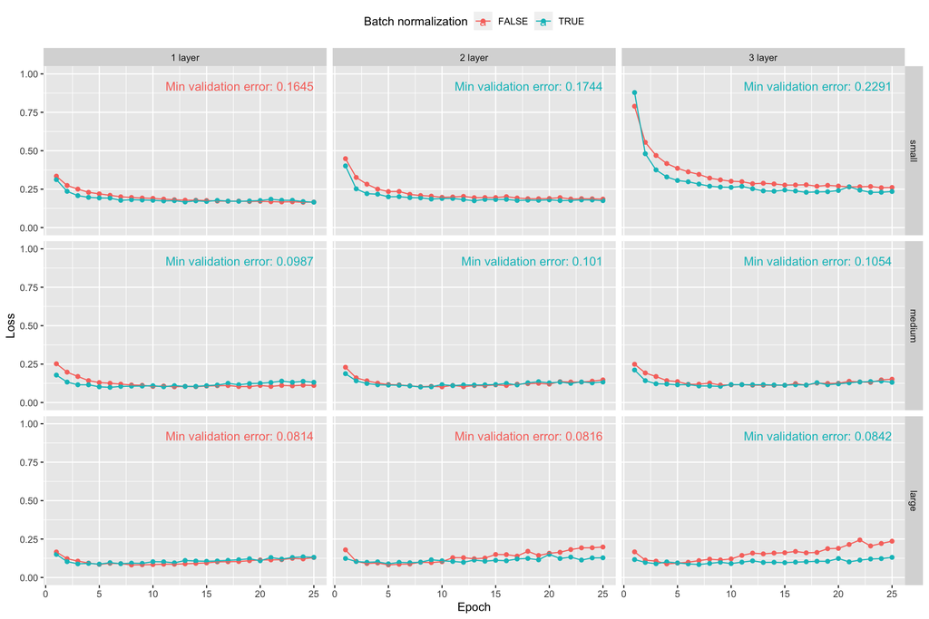

The effect of batch normalization on validation loss for various model capacities.

```r
df2 <- df %>%
  mutate(`Batch normalization` = FALSE) %>%
  bind_rows(df_batch) %>%
  filter(Validation == "Validation error")

best <- df2 %>%
  filter(Validation == "Validation error") %>%
  group_by(`Middle layers`, `Number of nodes`) %>%
  filter(Loss == min(Loss)) %>%
  mutate(label = paste("Min validation error:", round(Loss, 4)))

ggplot(df2, aes(epoch, Loss, color = `Batch normalization`)) +
  geom_text(data = best, aes(x = 25, y = 0.95, label = label), size = 4, hjust = 1, vjust = 1) +
  geom_point() +
  geom_line() +
  facet_grid(`Number of nodes` ~ `Middle layers`, scales = "free_y") +
  scale_y_continuous(limits = c(0, 1)) +
  xlab("Epoch") +
  scale_color_discrete("Batch normalization") +
  theme(legend.position = "top")
```

## Regularization

Regularization is generally a good practice for overfitting issue. Here we explore $L_1$ and $L_2$ normalization:

Here the code for a model with batch normalization and $L_2$ regularization.

```r
model_w_reg <- keras_model_sequential() %>%

  # Network architecture with L1 regularization and batch normalization
  layer_dense(units = 256, activation = "relu", input_shape = ncol(mnist_x),
              kernel_regularizer = regularizer_l2(0.001)) %>%
  layer_batch_normalization() %>%
  layer_dense(units = 128, activation = "relu",
              kernel_regularizer = regularizer_l2(0.001)) %>%
  layer_batch_normalization() %>%
  layer_dense(units = 64, activation = "relu",
              kernel_regularizer = regularizer_l2(0.001)) %>%
  layer_batch_normalization() %>%
  layer_dense(units = 10, activation = "softmax") %>%

  # Backpropagation
  compile(
    loss = "categorical_crossentropy",
    optimizer = optimizer_rmsprop(),
    metrics = c("accuracy")
  )
```

### Task

Present the result of the model with 3-layer with 256, 128 and 64 nodes per respective layer, with batch normalization and with $L_2$ regularization components.

```r
fit1 <- model_w_reg %>%
  fit(
    x = mnist_x,
    y = mnist_y,
    epochs = 25,
    batch_size = 128,
    validation_split = 0.2,
    verbose = FALSE
  )
fit1
```

```
Final epoch (plot to see history):
        loss: 0.09947
    accuracy: 0.9851
    val_loss: 0.1819
val_accuracy: 0.966
```

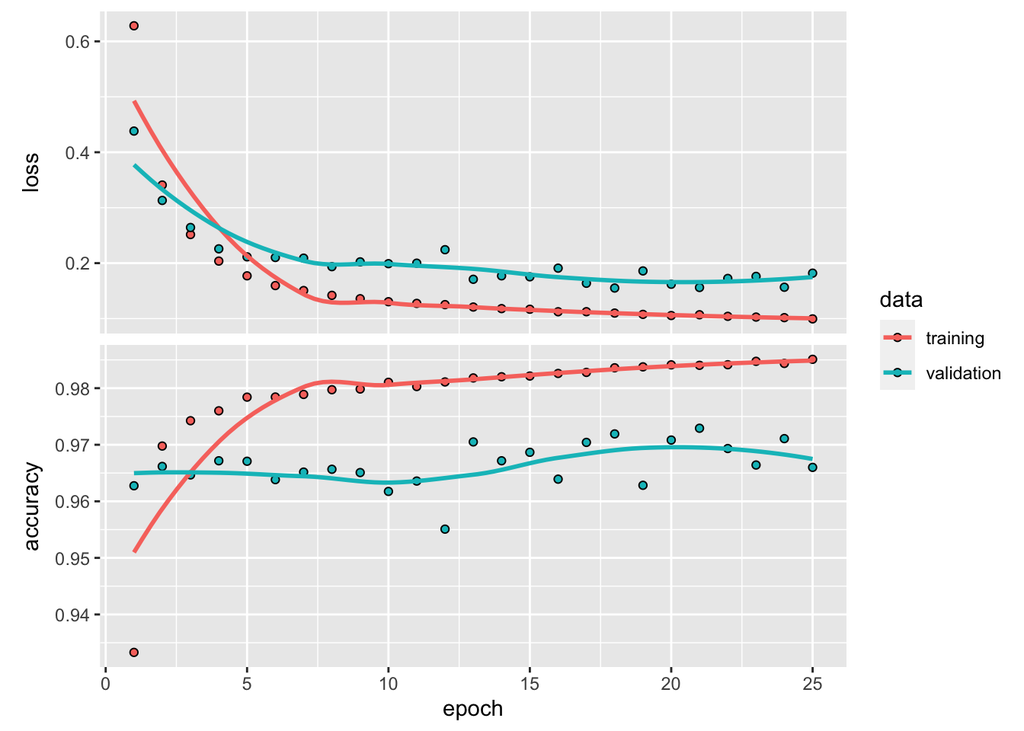

```r
plot(fit1)
```

Is the $L_2$ improved your model ?

## Dropout

An another avenue for overfitting issue is to use the **dropout** strategy.

```r
model_w_drop <- keras_model_sequential() %>%

  # Network architecture with 20% dropout
  layer_dense(units = 256, activation = "relu", input_shape = ncol(mnist_x)) %>%
  layer_dropout(rate = 0.2) %>%
  layer_dense(units = 128, activation = "relu") %>%
  layer_dropout(rate = 0.2) %>%
  layer_dense(units = 64, activation = "relu") %>%
  layer_dropout(rate = 0.2) %>%
  layer_dense(units = 10, activation = "softmax") %>%

  # Backpropagation
  compile(
    loss = "categorical_crossentropy",
    optimizer = optimizer_rmsprop(),
    metrics = c("accuracy")
  )
```

Here we compare 3 models: baseline, batch normalization and dropout + batch normalization

```r
fit_baseline <- keras_model_sequential() %>%
  layer_dense(units = 256, activation = "relu", input_shape = ncol(mnist_x)) %>%
  layer_dense(units = 128, activation = "relu") %>%
  layer_dense(units = 64, activation = "relu") %>%
  layer_dense(units = 10, activation = "softmax") %>%
  compiler() %>%
  fit(
    x = mnist_x,
    y = mnist_y,
    epochs = 35,
    batch_size = 128,
    validation_split = 0.2,
    verbose = FALSE
  )

fit_norm <- keras_model_sequential() %>%
  layer_dense(units = 256, activation = "relu", input_shape = ncol(mnist_x)) %>%
  layer_batch_normalization() %>%
  layer_dense(units = 128, activation = "relu") %>%
  layer_batch_normalization() %>%
  layer_dense(units = 64, activation = "relu") %>%
  layer_batch_normalization() %>%
  layer_dense(units = 10, activation = "softmax") %>%
  compiler() %>%
  fit(
    x = mnist_x,
    y = mnist_y,
    epochs = 35,
    batch_size = 128,
    validation_split = 0.2,
    verbose = FALSE
  )

fit_reg <- keras_model_sequential() %>%
  layer_dense(units = 256, activation = "relu", input_shape = ncol(mnist_x)) %>%
  layer_batch_normalization() %>%
  layer_dropout(rate = 0.4) %>%
  layer_dense(units = 128, activation = "relu") %>%
  layer_batch_normalization() %>%
  layer_dropout(rate = 0.3) %>%
  layer_dense(units = 64, activation = "relu") %>%
  layer_batch_normalization() %>%
  layer_dropout(rate = 0.2) %>%
  layer_dense(units = 10, activation = "softmax") %>%
  compiler() %>%
  fit(
    x = mnist_x,
    y = mnist_y,
    epochs = 35,
    batch_size = 128,
    validation_split = 0.2,
    verbose = FALSE
  )

models <- ls(pattern = "fit_")
df_reg <- models %>%
  map(get) %>%
  map(~ data.frame(
    `Validation error` = .$metrics$val_loss,
    `Training error`   = .$metrics$loss,
    epoch = seq_len(.$params$epoch)
    )) %>%
  map2_df(models, ~ mutate(.x, model = .y)) %>%
  mutate(Model = case_when(
    model == "fit_baseline" ~ "Baseline",
    model == "fit_norm"     ~ "Baseline + batch normalization",
    model == "fit_reg"      ~ "Baseline + batch normalization + dropout"
  )) %>%
  gather(Validation, Loss, Validation.error:Training.error)
```

- We plot the results

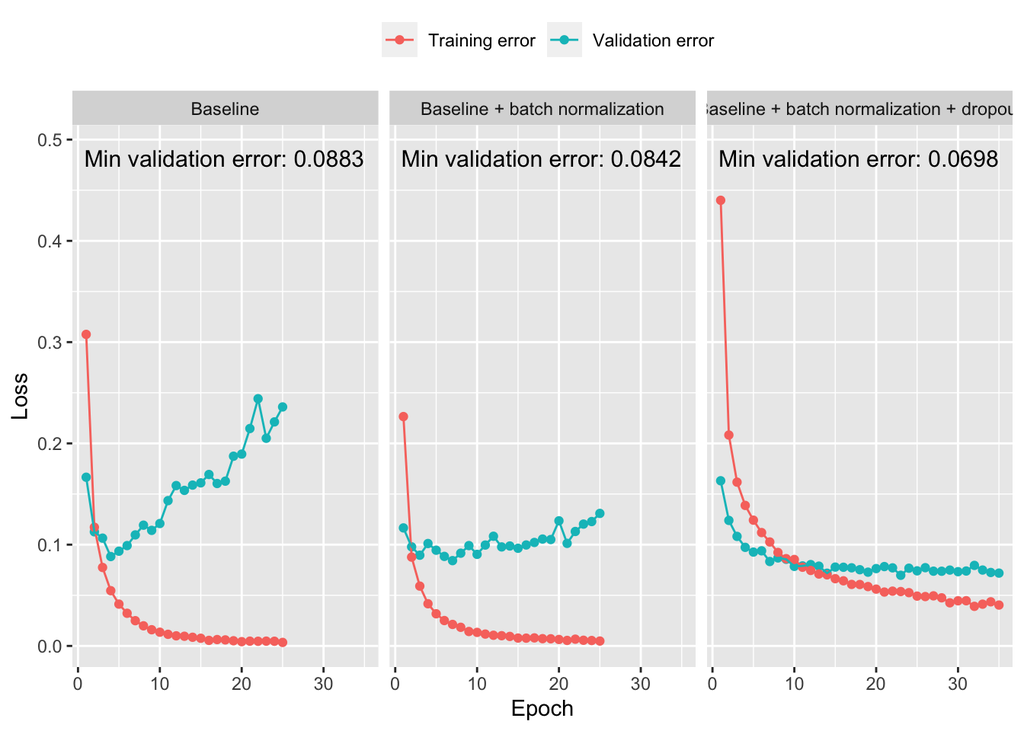

The effect of regularization with dropout on validation loss.

```r
baseline <- df %>%
  filter(`Middle layers` == "3 layer", `Number of nodes` == "large") %>%
  mutate(Model = "Baseline") %>%
  select(epoch, Model, Validation, Loss)
batch <- df_batch %>%
  filter(`Middle layers` == "3 layer", `Number of nodes` == "large") %>%
  mutate(Model = "Baseline + batch normalization") %>%
  select(epoch, Model, Validation, Loss)
df_reg <- df_reg %>%
  select(-model) %>%
  filter(Model == "Baseline + batch normalization + dropout") %>%
  mutate(Validation = stringr::str_replace_all(Validation, "\\.", " ")) %>%
  bind_rows(batch, baseline)

best <- df_reg %>%
  filter(Validation == "Validation error") %>%
  group_by(Model) %>%
  filter(Loss == min(Loss)) %>%
  mutate(label = paste("Min validation error:", round(Loss, 4)))

ggplot(df_reg, aes(epoch, Loss)) +
  geom_text(data = best, aes(x = 35, y = 0.49, label = label), size = 4, hjust = 1, vjust = 1) +
  geom_point(aes(color = Validation)) +
  geom_line(aes(color = Validation)) +
  facet_wrap(~ Model) +
  xlab("Epoch") +
  theme(legend.title = element_blank(),
        legend.position = "top")
```

Task: What are your conclusions ?

## What about the initialization of the weight

Keep in mind that weight initialization can have an impact on both the convergence rate and the accuracy of your network. In **Keras**, the argument **kernel_initializer** in the function **layer_dense** allows us to set up different weight initialization. The default is the “Glorot uniform” which draws samples from a uniform within $[-a,a]$ where $a=\sqrt{\frac{6}{(fan_i+fan_o)}}$ where $fan_i$ is the number of inputs in the weight tensor and $fan_o$ is the number of output in the weight tensor.

```r
fit_reg_init <- keras_model_sequential() %>%
  layer_dense(units = 256, activation = "relu", kernel_initializer=initializer_random_normal(),input_shape = ncol(mnist_x)) %>%
  layer_batch_normalization() %>%
  layer_dropout(rate = 0.4) %>%
  layer_dense(units = 128, kernel_initializer=initializer_random_normal(),activation = "relu") %>%
  layer_batch_normalization() %>%
  layer_dropout(rate = 0.3) %>%
  layer_dense(units = 64, kernel_initializer=initializer_random_normal(),activation = "relu") %>%
  layer_batch_normalization() %>%
  layer_dropout(rate = 0.2) %>%
  layer_dense(units = 10, kernel_initializer=initializer_random_normal(),activation = "softmax") %>%
  compiler() %>%
  fit(
    x = mnist_x,
    y = mnist_y,
    epochs = 35,
    batch_size = 128,
    validation_split = 0.2,
    verbose = FALSE
  )
fit_reg_init
```

```
Final epoch (plot to see history):
        loss: 0.03999
    accuracy: 0.9872
    val_loss: 0.0771
val_accuracy: 0.9811
```

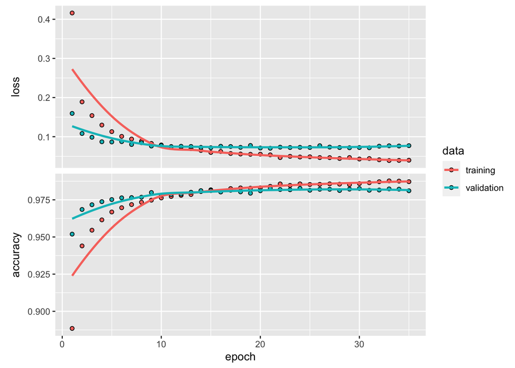

```r
plot(fit_reg_init)
```

Do you see any differences ? Is it better ?

## Early stop

You can also adust the number of “epoch” by adding **callback_early_stopping(patience = 5)** to stop training if the loss has not improved after 5 epochs.

```r
# set plot.keras_training_history in your global env to call user functions
plot.keras_training_history <- keras:::plot.keras_training_history
environment(plot.keras_training_history) <- globalenv()

# replace as.dataframe with custom function
as.data.frame.keras_training_history <- function (x, ...){

 if (tensorflow::tf_version() < "2.2")
  x$metrics <- x$metrics[x$params$metrics]
 values <- x$metrics

 # pad <- x$params$epochs - length(values$loss)
 # pad_data <- list()
 # for (metric in x$params$metrics) pad_data[[metric]] <- rep_len(NA,
 #                                                                pad)
 # values <- rbind(values, pad_data)

 values[] <- lapply(values, `length<-`, x$params$epochs)
 df <- data.frame(epoch = seq_len(x$params$epochs), value = unlist(values),
                  metric = rep(sub("^val_", "", names(x$metrics)), each = x$params$epochs),
                  data = rep(grepl("^val_", names(x$metrics)), each = x$params$epochs))
 rownames(df) <- NULL
 df$data <- factor(df$data, c(FALSE, TRUE), c("training", "validation"))
 df$metric <- factor(df$metric, unique(sub("^val_", "", names(x$metrics))))
 df
}
```

```r
model_final <- keras_model_sequential() %>%
  layer_dense(units = 256, activation = "relu", kernel_initializer=initializer_random_normal(),input_shape = ncol(mnist_x)) %>%
  layer_batch_normalization() %>%
  layer_dropout(rate = 0.4) %>%
  layer_dense(units = 128, kernel_initializer=initializer_random_normal(),activation = "relu") %>%
  layer_batch_normalization() %>%
  layer_dropout(rate = 0.3) %>%
  layer_dense(units = 64, kernel_initializer=initializer_random_normal(),activation = "relu") %>%
  layer_batch_normalization() %>%
  layer_dropout(rate = 0.2) %>%
  layer_dense(units = 10, kernel_initializer=initializer_random_normal(),activation = "softmax") %>%
  compile(
    loss = 'categorical_crossentropy',
    optimizer = optimizer_rmsprop(),
    metrics = c('accuracy')
  )

model_final.fit <- model_final %>%
  fit(
    x = mnist_x,
    y = mnist_y,
    epochs = 35,
    batch_size = 128,
    validation_split = 0.2,
    callbacks = list(callback_early_stopping(patience = 5)),
    verbose = FALSE
  )

model_final.fit
```

```
Final epoch (plot to see history):
        loss: 0.04788
    accuracy: 0.9849
    val_loss: 0.07768
val_accuracy: 0.9808
```

```r
# Optimal
min(model_final.fit$metrics$val_loss)
```

```
[1] 0.07196002
```

```r
max(model_final.fit$metrics$val_acc)
```

```
[1] 0.9816667
```

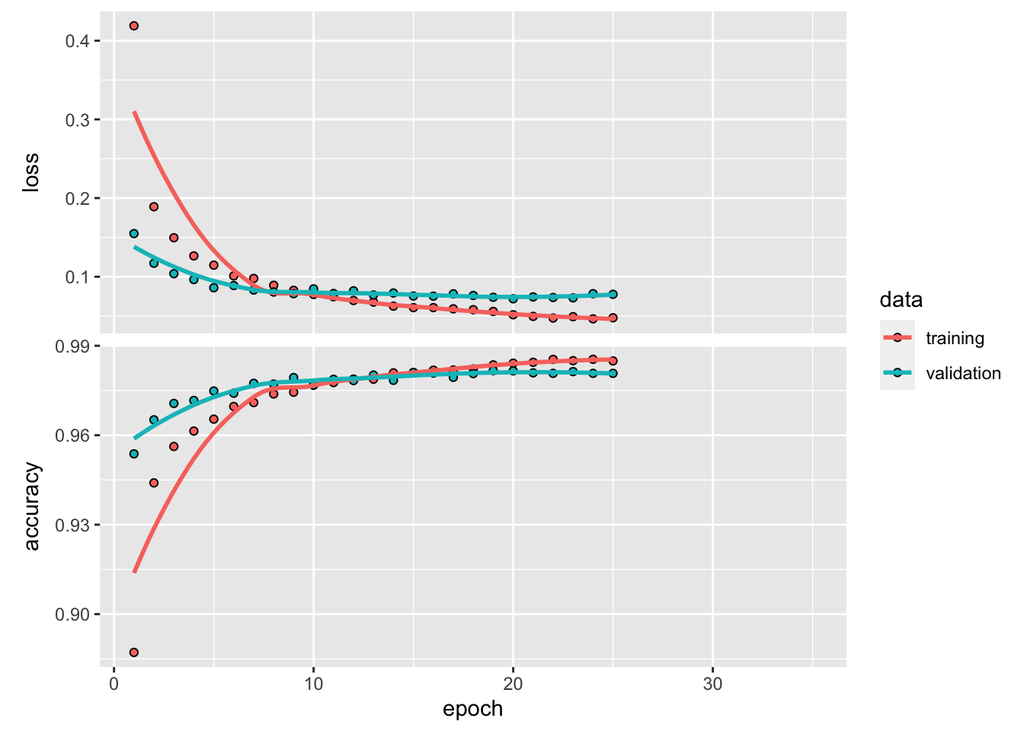

Training and validation performance on our 3-layer large network with dropout.

```r
plot(model_final.fit)
```

## Final Task

Present the performance of your final model on the test set:

- confusion matrix
- accuracy

### Performance

```r
#pred.final <- model_final%>%predict_classes(mnist_x_test[,])
pred.final <-model_final %>% predict(mnist_x_test[,]) %>% k_argmax()
confusionMatrix(as.factor(as.vector(pred.final)),factor(mnist_y_test))->res
res$table
```

```
          Reference
Prediction    0    1    2    3    4    5    6    7    8    9
         0  971    0    3    0    1    2    4    1    3    4
         1    1 1127    1    0    0    0    2    2    2    4
         2    0    3 1011    6    4    0    0    6    1    0
         3    2    1    1  990    0    6    0    0    4    6
         4    0    0    3    0  956    1    2    0    3    5
         5    1    0    0    5    0  869    3    0    3    2
         6    2    2    3    0    4    7  946    0    0    0
         7    1    1    7    5    2    2    0 1016    8    5
         8    2    1    3    2    1    2    1    1  948    0
         9    0    0    0    2   14    3    0    2    2  983
```

```r
res$overall[1]
```

```
Accuracy
  0.9817
```